# 07_analysis_3

Authors

Kacper Maciejewski (s243548)

Sofia Russo (252054)

Aleksandra Wozniak (253713)

Gabriel Loayza (252608)

Dagmar Geevers (252256)

# 01 Load Data

# Get cancer stemness indexes from the article supplement

We would like to use pre-computed stemness indexes (mostly mRNAsi) from the Malta et al. study.

> Table S1: Stemness Indices Derived for All PanCancer 33 TCGA Cohort, Related to Figure 1

As direct curl download is forbidden from the Cell website, the easiest will be that you download the CSV on your own in the browser using the link below.

```
https://www.cell.com/cms/10.1016/j.cell.2018.03.034/attachment/37f8d8d0-af00-404b-9bce-2d7d1d6a1a0d/mmc1.xlsx
```

Save the file under `/_raw/mmc1.xlsx` in the project directory.

# Get expression and clinical data from [cBioPortal](https://docs.cbioportal.org/web-api-and-clients/#r-clients)

We will aim to get exactly the same data as analyzed in [this](https://pubmed.ncbi.nlm.nih.gov/39063083/) article.

## Install and load libraries

## Examine available studies

```r
cbio <- cBioPortal()
print(getStudies(cbio)$studyId)
```

```
 [1] "difg_glass"                       "brca_aurora_2023"
 [3] "pcpg_tcga_pan_can_atlas_2018"     "coadread_tcga_pan_can_atlas_2018"
 [5] "ucec_tcga_pan_can_atlas_2018"     "uvm_tcga_pan_can_atlas_2018"
 [7] "chol_tcga_pan_can_atlas_2018"     "paad_tcga_pan_can_atlas_2018"
 [9] "thca_tcga_pan_can_atlas_2018"     "cesc_tcga_pan_can_atlas_2018"
[11] "thym_tcga_pan_can_atlas_2018"     "hnsc_tcga_pan_can_atlas_2018"
[13] "ov_tcga_pan_can_atlas_2018"       "skcm_tcga_pan_can_atlas_2018"
[15] "lusc_tcga_pan_can_atlas_2018"     "sarc_tcga_pan_can_atlas_2018"
[17] "acc_tcga_pan_can_atlas_2018"      "pancan_pcawg_2020"
[19] "pancan_pcawg_2020"                "lgg_tcga_pan_can_atlas_2018"
[21] "lihc_tcga_pan_can_atlas_2018"     "brca_tcga_pan_can_atlas_2018"
[23] "msk_spectrum_tme_2022"            "msk_spectrum_tme_2022"
[25] "msk_spectrum_tme_2022"            "msk_spectrum_tme_2022"
[27] "msk_spectrum_tme_2022"            "msk_spectrum_tme_2022"
[29] "tgct_tcga_pan_can_atlas_2018"     "dlbc_tcga_pan_can_atlas_2018"
[31] "kirc_tcga_pan_can_atlas_2018"     "prad_tcga_pan_can_atlas_2018"
[33] "gbm_tcga_pan_can_atlas_2018"      "ucs_tcga_pan_can_atlas_2018"
[35] "blca_tcga_pan_can_atlas_2018"     "kich_tcga_pan_can_atlas_2018"
[37] "kirp_tcga_pan_can_atlas_2018"     "brca_hta9_htan_2022"
[39] "luad_tcga_pan_can_atlas_2018"     "meso_tcga_pan_can_atlas_2018"
[41] "stad_tcga_pan_can_atlas_2018"     "ovary_geomx_gray_foundation_2024"
[43] "crc_hta11_htan_2021"              "crc_hta11_htan_2021"
[45] "crc_hta11_htan_2021"              "crc_hta11_htan_2021"
[47] "esca_tcga_pan_can_atlas_2018"     "crc_orion_2024"
[49] "crc_orion_2024"                   "crc_orion_2024"
```

## Define genes and studies

```r
cbio <- cBioPortal()

genes <- c(
  "HDAC1","HDAC2","HDAC3","HDAC8",
  "HDAC4","HDAC5","HDAC7","HDAC9",
  "HDAC6","HDAC10",
  "SIRT1","SIRT2","SIRT3","SIRT4","SIRT5","SIRT6","SIRT7",
  "HDAC11"
)

studies <- c(
  "blca_tcga_pan_can_atlas_2018",
  "brca_tcga_pan_can_atlas_2018",
  "cesc_tcga_pan_can_atlas_2018",
  "coadread_tcga_pan_can_atlas_2018",
  "esca_tcga_pan_can_atlas_2018",
  "gbm_tcga_pan_can_atlas_2018",
  "hnsc_tcga_pan_can_atlas_2018",
  "kirc_tcga_pan_can_atlas_2018",
  "kirp_tcga_pan_can_atlas_2018",
  "lgg_tcga_pan_can_atlas_2018",
  "lihc_tcga_pan_can_atlas_2018",
  "luad_tcga_pan_can_atlas_2018",
  "lusc_tcga_pan_can_atlas_2018",
  "ov_tcga_pan_can_atlas_2018",
  "paad_tcga_pan_can_atlas_2018",
  "prad_tcga_pan_can_atlas_2018",
  "sarc_tcga_pan_can_atlas_2018",
  "skcm_tcga_pan_can_atlas_2018",
  "stad_tcga_pan_can_atlas_2018",
  "tgct_tcga_pan_can_atlas_2018",
  "thca_tcga_pan_can_atlas_2018",
  "ucec_tcga_pan_can_atlas_2018"
)
```

## Define backbone for fetching

```r
study_tbl <- tibble(
  studyId   = studies,
  profileId = paste0(studies, "_rna_seq_v2_mrna")
)
```

## Fetch clinical data

```r
study_tbl %>%
  mutate(
    clin = map(studyId, ~ clinicalData(cbio, .x)),
    file = paste0("../_raw", "/clinical_", studyId, ".csv"),
    written = map2(clin, file, write_csv)
  ) %>%
invisible()
```

# 02 Clean Data

# Mege expression data with clinical features

## Load libraries

```r
library(tidyverse)
```

## List all downloaded files

```r
files <- tibble(
  path = list.files("../_raw", pattern = "*.csv", full.names = TRUE),
  name = basename(path),
  type = case_when(
    str_starts(name, "expr_") ~ "expr",
    str_starts(name, "clinical_") ~ "clin",
    TRUE ~ NA_character_
  ),
  studyId = name %>%
    str_remove("^expr_") %>%
    str_remove("^clinical_") %>%
    str_remove("\\.csv$")
)

expr_tbl <- files %>% filter(type == "expr")
clin_tbl <- files %>% filter(type == "clin")
```

## Read, pivot wide, deduplicate, join

As we would like to have one entry per patient (as there is in clinical data) and expression data may contain the sequencing for many sample slices from the very patient, we will deduplicate expression entries by averaging the expressions across all slices.

```r
merged_tbl <- expr_tbl %>%
  left_join(clin_tbl, by = "studyId", suffix = c("_expr", "_clin")) %>%
  mutate(

    # Read expression data with deduplication
    expr = map(path_expr, ~ read_csv(.x, show_col_types = FALSE) %>%
                 group_by(patientId, hugoGeneSymbol) %>%
                 summarise(value = mean(value, na.rm = TRUE), .groups = "drop") %>%
                 pivot_wider(
                   names_from = hugoGeneSymbol,
                   values_from = value
                 )),

    # Read clinical data
    clin = map(path_clin, ~ read_csv(.x, show_col_types = FALSE) %>%
                 mutate(across(everything(), as.character))),

    merged = map2(expr, clin, ~ left_join(.x, .y,
                                          by = "patientId",
                                          relationship = "many-to-many"))
  )
```

## Unnest the dataframe

```r
full_tbl <- merged_tbl %>%
  select(studyId, merged) %>%
  unnest(merged)
```

# Merge stemness indexes

## Load libraries

```r
library(readxl)
```

## Load stemness data

Make sure you downloaded it manually before.

```r
mmc1_path <- file.path("../_raw", "mmc1.xlsx")

# replace "Table S1" with the actual sheet name if different
mmc1 <- read_xlsx(mmc1_path, sheet = "StemnessScores_RNAexp")
```

## Merge stemness data with expression and clinical features

`TCGAlong.id` from the `mmc1.xlsx` is in the long format e.g. *TCGA-04-1348-01A-01R-1565-13*, specyfing the exact expression-based patient slice.

We want only the first 12 characters (e.g. *TCGA-PG-A917*) as these are master and unique patient IDs in the TCGA.

In the case of duplicates, as previosuly, we will average the stemness value for those.

```r
# clean the patient field
mmc1_clean <- mmc1 %>%
  mutate(
    patientId = substr(TCGAlong.id, 1, 12)
  ) %>%
  group_by(patientId) %>%
  summarise(
    across(where(is.numeric), ~ mean(.x, na.rm = TRUE)),
    .groups = "drop"
  )

full_tbl_mmc1 <- full_tbl %>%
  left_join(mmc1_clean, by = "patientId")
```

# Sanity check

## Number of samples and column names

```r
n_samples <- full_tbl_mmc1 %>%
  distinct(patientId) %>%
  nrow()

print(n_samples)
```

```
[1] 9142
```

```r
print(colnames(full_tbl_mmc1))
```

```
 [1] "studyId"
 [2] "patientId"
 [3] "HDAC1"
 [4] "HDAC10"
 [5] "HDAC11"
 [6] "HDAC2"
 [7] "HDAC3"
 [8] "HDAC4"
 [9] "HDAC5"
[10] "HDAC6"
[11] "HDAC7"
[12] "HDAC8"
[13] "HDAC9"
[14] "SIRT1"
[15] "SIRT2"
```

[output cut: 69 more lines]

## Clean extra rows from the merge

```r
full_tbl_mmc1 <- full_tbl_mmc1 %>%
  select(
    Cancer = studyId,
    patientId,
    HDAC1, HDAC2, HDAC3, HDAC4, HDAC5,
    HDAC6, HDAC7, HDAC8, HDAC9, HDAC10, HDAC11,
    SIRT1, SIRT2, SIRT3, SIRT4, SIRT5, SIRT6, SIRT7,
    mRNAsi,
    Grade = GRADE,
    Stage = AJCC_PATHOLOGIC_TUMOR_STAGE,
    DFS_MONTHS, DFS_STATUS,
    OS_MONTHS,  OS_STATUS
  )
```

## Save final CSV file

```r
write_csv(full_tbl_mmc1, "../data/02_dat_clean.csv")
```

# 03 Augment Data

# Augment data

## Load libraries and data from previous step

```r
library(tidyverse)

dat <- read.csv("../data/02_dat_clean.csv")
```

## Normalize stage and grade naming scheme

First, we need to know what values are there, so we print unique ones.

```r
# Print unique values in Grade
unique(dat$Grade)
```

```
[1] "High Grade" "Low Grade"  NA           "G3"         "G2"
[6] "G1"         "GX"         "G4"         "GB"
```

```r
# Print unique values in Stage
unique(dat$Stage)
```

```
 [1] "STAGE IV"         "STAGE III"        "STAGE II"         "STAGE I"
 [5] NA                 "STAGE X"          "STAGE IIB"        "STAGE IA"
 [9] "STAGE IIIA"       "STAGE IIA"        "STAGE IIIC"       "STAGE IB"
[13] "STAGE IIIB"       "STAGE IVA"        "STAGE IIC"        "STAGE IVB"
[17] "STAGE IVC"        "STAGE I/II (NOS)" "STAGE 0"          "STAGE IS"
```

### Convert staging and grading

```r
#STAGE FUNCTION
stage_to_num <- function(stage) {
  dplyr::case_when(
    stage == "STAGE 0" ~ 0,
    stage == "STAGE IS" ~ 0,
    stage %in% c("STAGE I", "STAGE IA", "STAGE IB") ~ 1,
    stage %in% c("STAGE II", "STAGE IIA", "STAGE IIB", "STAGE IIC") ~ 2,
    stage %in% c("STAGE III", "STAGE IIIA", "STAGE IIIB", "STAGE IIIC") ~ 3,
    stage %in% c("STAGE IV", "STAGE IVA", "STAGE IVB", "STAGE IVC") ~ 4,
    stage == "STAGE I/II (NOS)" ~ 1.5,
    stage == "STAGE X" ~ NA,
    TRUE ~ NA
  )
}

#GRADE FUNCTION
grade_to_num <- function(grade) {
  dplyr::case_when(
    grade == "Low Grade"  ~ 1,
    grade == "High Grade" ~ 4,
    grade == "G1" ~ 1,
    grade == "G2" ~ 2,
    grade == "G3" ~ 3,
    grade == "G4" ~ 4,
    grade == "GX" ~ NA,
    TRUE ~ NA
  )
}

# Apply the new naming scheme
dat <- dat %>%
  mutate(
    Grade_num = grade_to_num(Grade),
    Stage_num = stage_to_num(Stage)
  )
```

## Normalize study names

```r
dat <- dat %>%
  mutate(
    Cancer = toupper(substr(Cancer, 1, 4))
  )
```

## Write augmented data

```r
write.csv(dat, "../data/03_dat_aug.csv", row.names = FALSE)
```

# Examine final structure

```r
colnames(dat)
```

```
 [1] "Cancer"     "patientId"  "HDAC1"      "HDAC2"      "HDAC3"
 [6] "HDAC4"      "HDAC5"      "HDAC6"      "HDAC7"      "HDAC8"
[11] "HDAC9"      "HDAC10"     "HDAC11"     "SIRT1"      "SIRT2"
[16] "SIRT3"      "SIRT4"      "SIRT5"      "SIRT6"      "SIRT7"
[21] "mRNAsi"     "Grade"      "Stage"      "DFS_MONTHS" "DFS_STATUS"
[26] "OS_MONTHS"  "OS_STATUS"  "Grade_num"  "Stage_num"
```

```r
head(dat)
```

```
  Cancer    patientId   HDAC1   HDAC2    HDAC3    HDAC4    HDAC5    HDAC6
1   BLCA TCGA-2F-A9KO 3405.83 2490.96  887.464 170.8450  889.796  907.289
2   BLCA TCGA-2F-A9KP 3385.35 3150.64 1308.780  90.7199  514.357  782.771
3   BLCA TCGA-2F-A9KQ 3305.05 1467.78 1319.890  67.2230  459.898 1137.690
4   BLCA TCGA-2F-A9KR 5070.12 1778.84 1847.220 422.6290  462.517 1524.790
5   BLCA TCGA-2F-A9KT 2404.75 2455.06  822.499 158.8470 2222.160  881.289
6   BLCA TCGA-2F-A9KW 3491.47 2893.50  828.359 203.6860  896.429  758.718
    HDAC7   HDAC8   HDAC9   HDAC10  HDAC11   SIRT1    SIRT2   SIRT3   SIRT4
1 2498.54 401.166 37.9009 1141.140 360.350 532.945  914.286 409.079 15.1603
2 2204.33 387.849  6.6583  576.255 486.891 416.147  923.845 479.134  7.0745
3 3190.54 350.950 31.0617  757.228 622.160 479.370  993.973 509.277 14.3718
4 3741.93 419.305 35.1399 1383.560 570.311 334.779 1445.010 392.180 15.6705
5 3258.90 325.608  5.0876 1949.300 630.865 321.651 1096.100 413.363 20.3505
6 2534.30 241.910 29.3224  675.128 220.442 647.188  607.393 562.441 12.0431
    SIRT5   SIRT6    SIRT7    mRNAsi      Grade     Stage DFS_MONTHS
1 408.746 461.224 1165.010 0.3827838 High Grade  STAGE IV         NA
2 414.066 481.898  633.375 0.4897023 High Grade  STAGE IV         NA
3 330.088 456.653  623.088 0.3546702 High Grade STAGE III   94.88115
4 430.701 601.177  984.867 0.3576302 High Grade STAGE III  101.45642
5 240.249 500.848  945.732 0.3634584 High Grade  STAGE II  108.95223
6 212.064 464.447 1190.180 0.4363244 High Grade STAGE III         NA
             DFS_STATUS  OS_MONTHS  OS_STATUS Grade_num Stage_num
1                  <NA>  24.131242 1:DECEASED         4         4
2                  <NA>  11.966992 1:DECEASED         4         4
3         0:DiseaseFree  94.881152   0:LIVING         4         3
4 1:Recurred/Progressed 104.645428 1:DECEASED         4         3
5         0:DiseaseFree 108.952231   0:LIVING         4         2
6                  <NA>   8.350593 1:DECEASED         4         3
```

# 04 Describe Data

# Describe Data

## Load data from previous step

```r
library(tidyverse)

dat <- read.csv("../data/03_dat_aug.csv")
```

## Number of patients per TCGA cohort

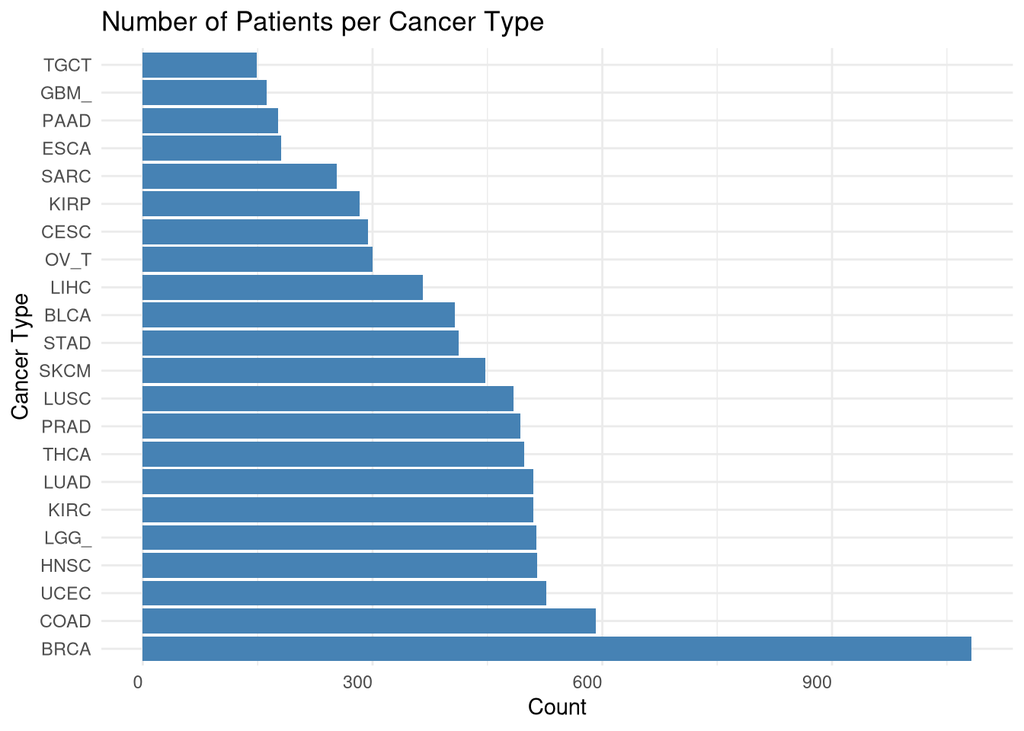

```r
p <- dat |> ggplot(aes(x = fct_infreq(Cancer))) +
  geom_bar(fill = "steelblue") +
  labs(title = "Number of Patients per Cancer Type",
       x = "Cancer Type", y = "Count") +
  theme_minimal() +
  theme(axis.text.x = element_text(angle = 0,
                                   hjust = 1)) +
  coord_flip() #The graph become horizontal

p
```

```r
ggsave("../results/04_key_plot_tcga_cohort.png", plot = p, width = 8, height = 6, dpi = 300)
```

This bar chart shows the distribution of patient counts across cancer types. Most cancer types have a relatively similar number of patients, except for BRCA, which is much larger, and a few cancers such as TGCT, GBM, and PAAD, which have noticeably smaller cohorts. Overall, the figure highlights an imbalance mainly driven by these extremes.Tumor grade distribution

## Tumo Grade Distribution

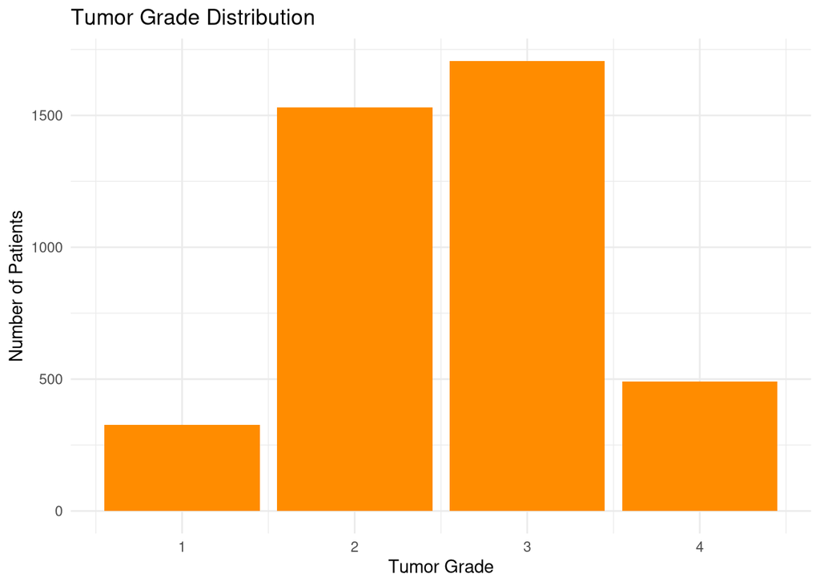

```r
p <- dat |> drop_na(Grade_num) |>
  ggplot(aes(x = Grade_num)) +
  geom_bar(fill = "darkorange") +
  labs(title = "Tumor Grade Distribution",
       x = "Tumor Grade",
       y = "Number of Patients") +
  theme_minimal()

p
```

```r
ggsave("../results/04_key_plot_grade_distribution.png", plot = p, width = 8, height = 6, dpi = 300)
```

The figure shows the Tumor Grade Distribution in all patients. Most of the patients had intermediate tumor grades (2-3). Meanwhile, the Tumor Grade 1 and 4 are noticeable smaller.

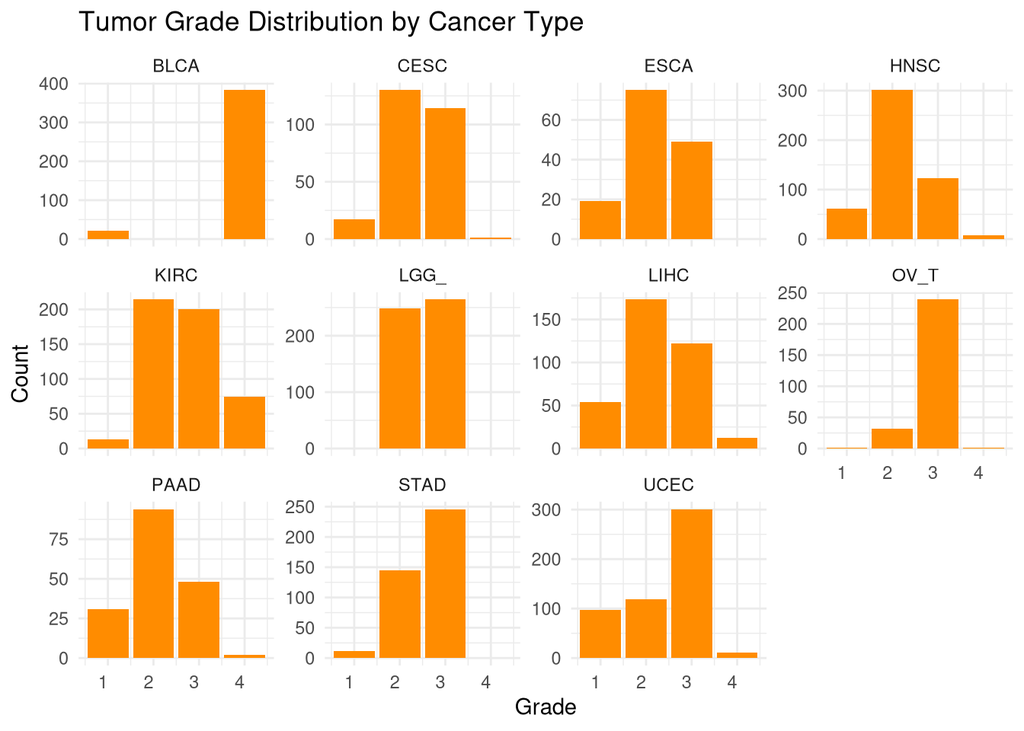

```r
p <- dat |> filter(!is.na(Grade_num))|>
  ggplot(aes(x = Grade_num)) +
  geom_bar(fill = "darkorange") +
  facet_wrap(~ Cancer, scales = "free_y") + #Applies distribution peer Cancer Type
  labs(title = "Tumor Grade Distribution by Cancer Type",
       x = "Grade",
       y = "Count") +
  theme_minimal() +
  theme(axis.text.x = element_text(angle = 0,
                                   hjust = 1))

p
```

```r
ggsave("../results/04_key_plot_grade_by_type.png", plot = p, width = 8, height = 6, dpi = 300)
```

## HDAC and SIRT gene expression

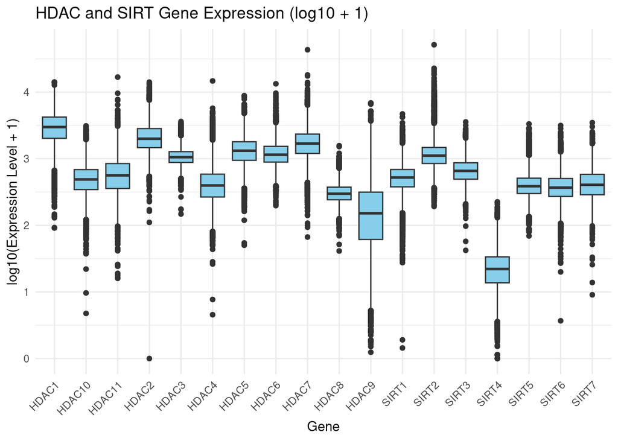

```r
p <- dat |> pivot_longer(cols = starts_with("HDAC") | starts_with("SIRT"),
                    names_to = "Gene",
                    values_to = "Expression") |>
  filter(!is.na(Expression) & Expression >= 0) |> #Avoid negative values
  mutate(Expression_log = log10(Expression + 1)) |> #Avoid 0 values become Inf
  ggplot(aes(x = Gene,
             y = Expression_log)) +
  geom_boxplot(fill = "skyblue") +
  labs(title = "HDAC and SIRT Gene Expression (log10 + 1)",
       x = "Gene",
       y = "log10(Expression Level + 1)") +
  theme_minimal() +
  theme(axis.text.x = element_text(angle = 45,
                                   hjust = 1))

p
```

```r
ggsave("../results/04_key_plot_gene_expression.png", plot = p, width = 8, height = 6, dpi = 300)
```

This figure shows the distribution of HDAC and SIRT gene expression levels across all samples. Expression values were transformed using log10(expression + 1) to avoid infinite or undefined values for genes with zero counts.

Overall, most genes display moderate expression with varying degrees of dispersion, while a few (HDAC9 and SIRT4) show broader variability and lower median levels. This highlights heterogeneity in expression patterns within the HDAC and SIRT families.

## Stemness index (mRNAsi)

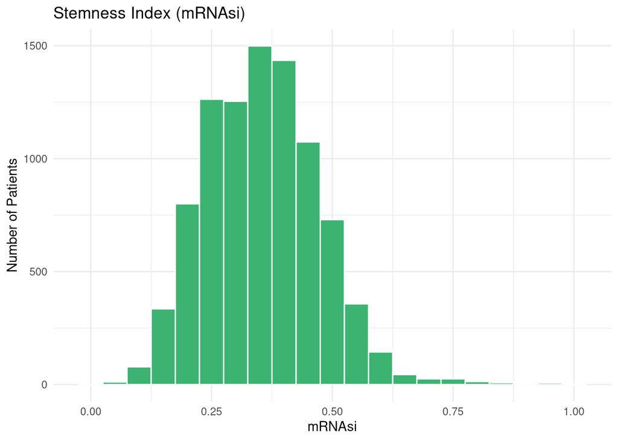

```r
p <- dat |> filter(!is.na(mRNAsi)) |>
  ggplot(aes(x = mRNAsi)) +
  geom_histogram(binwidth = 0.05, fill = "mediumseagreen", color = "white") +
  labs(title = "Stemness Index (mRNAsi)",
       x = "mRNAsi",
       y = "Number of Patients") +
  theme_minimal()

p
```

```r
ggsave("../results/04_key_plot_stemness.png", plot = p, width = 8, height = 6, dpi = 300)
```

This histogram shows the distribution of the stemness index (mRNAsi) across all patients. Most values fall between 0.20 and 0.45, with a clear peak around 0.30–0.35, indicating that the majority of tumors exhibit intermediate levels of stemness. Very low and very high mRNAsi values are relatively rare.

Next, we will examine how this distribution varies across tumor grades to explore whether higher stemness is associated with more aggressive (higher-grade) tumors.

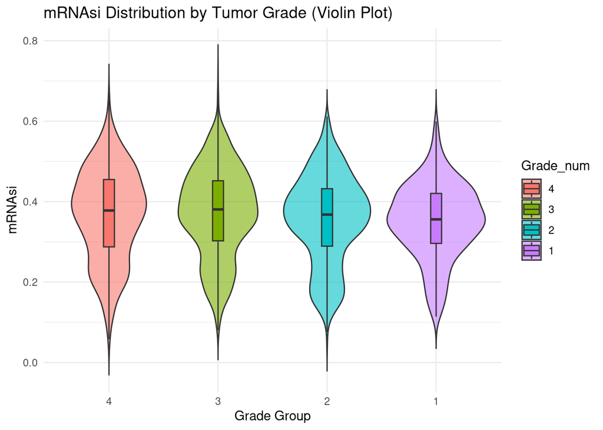

```r
p <- dat |>
  mutate(Grade_num = factor(Grade_num, levels = c("4","3", "2", "1"))) |>
  drop_na(mRNAsi, Grade_num) |>
  ggplot(aes(x = Grade_num,
             y = mRNAsi,
             fill = Grade_num)) +
  geom_violin(trim = FALSE, alpha = 0.6) +
  geom_boxplot(width = 0.1, outlier.shape = NA) +
  theme_minimal() +
  labs(title = "mRNAsi Distribution by Tumor Grade (Violin Plot)",
       x = "Grade Group", y = "mRNAsi")
p
```

```r
ggsave("../results/04_key_plot_violin.png", plot = p, width = 8, height = 6, dpi = 300)
```

This violin plot shows the distribution of mRNAsi across tumor grades (1–4). Overall, the median stemness values are similar across groups, with only a modest upward shift in higher grades (3 and 4). However, this difference is small and does not, by itself, indicate a statistically significant trend.

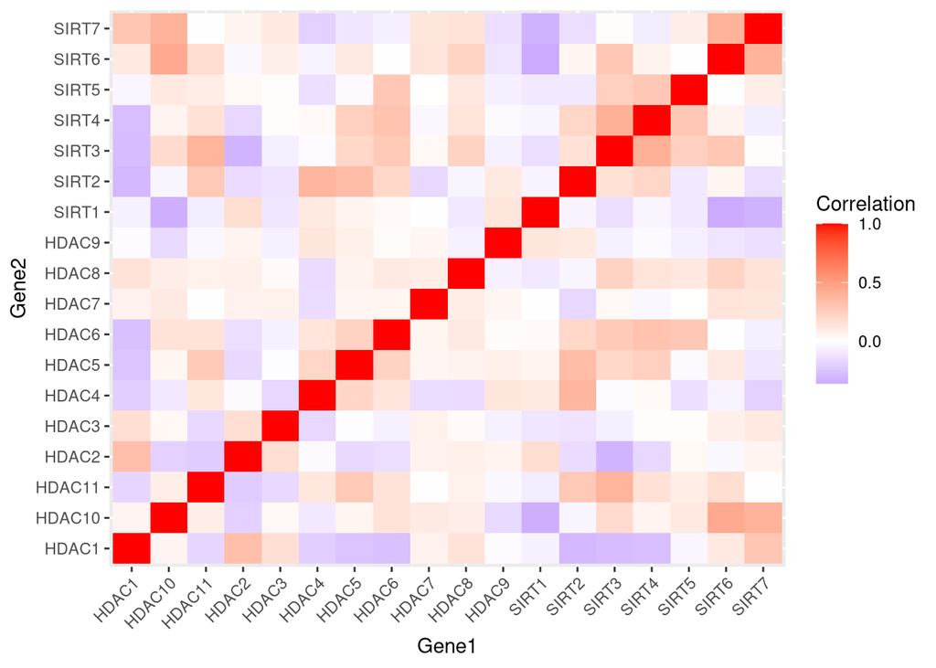

```r
p <- dat |>
  select(starts_with("HDAC"), starts_with("SIRT")) |>
  cor(use = "pairwise.complete.obs") |>
  as.data.frame() |>
  rownames_to_column("Gene1") |>
  pivot_longer(-Gene1, names_to = "Gene2", values_to = "Correlation") |>
  ggplot(aes(x = Gene1, y = Gene2, fill = Correlation)) +
  geom_tile() +
  scale_fill_gradient2(low = "blue", mid = "white", high = "red") +
  theme(axis.text.x = element_text(angle = 45, hjust = 1))
p
```

```r
ggsave("../results/04_key_plot_stemness.png", plot = p, width = 8, height = 6, dpi = 300)
```

# 05 Analysis Part 1

## Load libraries

```r
#rm(list=ls())
library(tidyverse)
library(ggplot2)
library(tidyr)
library(broom)
library(grid)
library(patchwork)
```

## Load data

```r
my_data <- read_csv("../data/02_dat_clean.csv", show_col_types = FALSE)
#view(my_data)
```

# FIGURE 1A

## 1.1 Cleaning and numbering the “Grade”

Grade is a microscopic assessment of the appearance of cancer cells, indicating how different they are from the normal cells.

- low grade- the cells are similar to healthy ones. The tumor is usually less agressive
- high grade- the cells are poorly differentiated or undifferentiated. The tumor is usually more agressive

```r
print(unique(my_data$Grade))
```

```
[1] "High Grade" "Low Grade"  NA           "G3"         "G2"
[6] "G1"         "GX"         "G4"         "GB"
```

```r
#converting descriptive text values to numierc values to enable statistical calculations
changed_data <- my_data %>%
  mutate(
    Grade_in_numbers = case_when(
#group 1: low malignacy
      Grade == "G1" ~ 1,
      Grade == "Low Grade" ~ 1,
#group 2: medium malignacy
      Grade == "G2" ~ 2,
#group 3: high malignacy
      Grade == "G3" ~ 3,
      Grade == "High Grade" ~ 3,
#group 4: the highest malignacy
      Grade == "G4" ~ 4,
      TRUE ~ NA_real_
    )
  ) %>%
  drop_na(Grade_in_numbers)
print(changed_data$Grade_in_numbers)
```

[output not shown]

[output cut: 95 more lines]

## 1.2 Standardization of tumor names

- long names from TCGA database are converted to short abbreviations

```r
changed_data$Cancer <- dplyr::recode(changed_data$Cancer,
  "blca_tcga_pan_can_atlas_2018"    = "BLCA",
  "brca_tcga_pan_can_atlas_2018"    = "BRCA",
  "cesc_tcga_pan_can_atlas_2018"    = "CESC",
  "coadread_tcga_pan_can_atlas_2018"= "COAD",
  "esca_tcga_pan_can_atlas_2018"    = "ESCA",
  "gbm_tcga_pan_can_atlas_2018"     = "GBM",
  "hnsc_tcga_pan_can_atlas_2018"    = "HNSC",
  "kirc_tcga_pan_can_atlas_2018"    = "KIRC",
  "kirp_tcga_pan_can_atlas_2018"    = "KIRP",
  "lgg_tcga_pan_can_atlas_2018"     = "LGG",
  "lihc_tcga_pan_can_atlas_2018"    = "LIHC",
  "luad_tcga_pan_can_atlas_2018"    = "LUAD",
  "lusc_tcga_pan_can_atlas_2018"    = "LUSC",
  "ov_tcga_pan_can_atlas_2018"      = "OV",
  "paad_tcga_pan_can_atlas_2018"    = "PAAD",
  "prad_tcga_pan_can_atlas_2018"    = "PRAD",
  "sarc_tcga_pan_can_atlas_2018"    = "SARC",
  "skcm_tcga_pan_can_atlas_2018"    = "SKCM",
  "stad_tcga_pan_can_atlas_2018"    = "STAD",
  "tgct_tcga_pan_can_atlas_2018"    = "TGCT",
  "thca_tcga_pan_can_atlas_2018"    = "THCA",
  "ucec_tcga_pan_can_atlas_2018"    = "UCEC"
)

#next step: filtering the data, leaving only the selected cancer types and arranging them in order on the graph
cancer_order <- c(
  "LIHC", "UCEC", "KIRC", "LGG",
  "OV", "PAAD",
  "HNSC", "ESCA", "CESC", "STAD",
  "COAD", "BLCA"
)
cancers_use <- intersect(cancer_order, unique(changed_data$Cancer))

changed_data <- changed_data %>%
  filter(Cancer %in% cancers_use)

changed_data$Cancer <- factor(changed_data$Cancer,
                              levels = cancers_use)
```

## 1.3 Selection of genes for analysis

```r
genes_to_test <- c(
#class I
  "HDAC3", "HDAC2", "HDAC1", "HDAC8",
#class IIA
  "HDAC7", "HDAC9", "HDAC5", "HDAC4",
#class III
  "SIRT1", "SIRT7", "SIRT6", "SIRT4", "SIRT3", "SIRT2", "SIRT5",
#class IIB
  "HDAC6", "HDAC10",
#class IV
  "HDAC11")
```

## 1.4 Statistical calculations- correlation

We want to see how the activity of gene “x” in patients with cancer “y” correlates with increasing malignancy.

For that we are using Spearman correlation, because it is resistant for asymmetry.

The result is the correlation coefficient ( rho) and statistical significance ( p value)

```r
#pivot_longer- this function changes format from wide to long format
s_correlation <- changed_data %>%
  pivot_longer(
    cols = any_of(genes_to_test),
    names_to = "gene",
    values_to = "expression"
  ) %>%
  #group for each pair (gene + cancer)
group_by(Cancer, gene) %>%
summarize(
    summary_test = broom::tidy(cor.test(expression, Grade_in_numbers, method ="spearman")), .groups = "drop"
  ) %>%
  unnest(summary_test) %>%
  select(Cancer, gene, rho = estimate, p.value)
```

## 1.5 Matrix_rho

heatmap requires data in matrix format

```r
matrix_rho <- s_correlation %>%
  select(gene, Cancer, rho) %>%
  pivot_wider(
    names_from = Cancer,
    values_from = rho
  ) %>%
  column_to_rownames("gene") %>%
  as.matrix()
```

## 1.6 Matrix_p

```r
matrix_p <- s_correlation %>%
  select(gene, Cancer, p.value) %>%
  pivot_wider(
    names_from = Cancer,
    values_from = p.value
  ) %>%
  column_to_rownames("gene") %>%
  as.matrix()

#filtering and sorting- without that R will sort the genes by alphabet
final_genes <- genes_to_test[genes_to_test %in% rownames(matrix_rho)]
final_cancers <- cancers_use[cancers_use %in% colnames(matrix_rho)]

#sorted versions
matrix_rho <- matrix_rho[final_genes, final_cancers, drop = FALSE]
matrix_p   <- matrix_p[final_genes, final_cancers, drop = FALSE]

#NA -> 0
matrix_rho_plot <- matrix_rho
matrix_rho_plot[is.na(matrix_rho_plot)] <- 0
```

## 1.7 Preparation of the final graph

```r
#adnotations-> annot_row creates a legend, assignment to classes
#data frame is created assigning each gene to the appropriate family
gene_classes <- c(
  HDAC3="class I",
  HDAC2="class I",
  HDAC1="class I",
  HDAC8="class I",

  HDAC7="class IIA",
  HDAC9="class IIA",
  HDAC5="class IIA",
  HDAC4="class IIA",

  HDAC6="class IIB",
  HDAC10="class IIB",

  SIRT1="class III",
  SIRT7="class III",
  SIRT6="class III",
  SIRT4="class III",
  SIRT3="class III",
  SIRT2="class III",
  SIRT5="class III",

  HDAC11="class IV"
)
#data frame for heatmap
annot_df <- data.frame(
  gene = final_genes,
  HDAC_family = gene_classes[final_genes]
)

#a BH correction is applied to the p-values to avoid false positives with multiple tests
matrix_p_dot <- matrix(p.adjust(as.vector(matrix_p), method = "BH"),
                       ncol = ncol(matrix_p),
                       nrow = nrow(matrix_p),
                       byrow = FALSE
)
#adding markers depending on p value
display_matrix <-
  ifelse(matrix_p_dot < 0.001, "■",
  ifelse(matrix_p_dot < 0.01,  "▲",
  ifelse(matrix_p_dot < 0.05,  "•", "")))


#color palette
my_breaks <- seq(-0.3, 0.3, length.out = 100)

my_colours <- colorRampPalette(c("blue","white", "red"))(100)


# data preparation for ggplot
df_long <- matrix_rho_plot %>%
  as.data.frame() %>%
  rownames_to_column("gene") %>%
  pivot_longer(-gene, names_to = "Cancer", values_to = "value")

df_long$Cancer <- factor(df_long$Cancer, levels = cancer_order)

df_long$label <- as.character(display_matrix)
df_long$label[df_long$label == ""] <- NA

#adnotations panel
p_annot <- ggplot(annot_df, aes(
    x=1,
    y=factor(gene, levels=rev(final_genes)),
    fill=HDAC_family)) +
  geom_tile() +
  scale_fill_manual(values=c(
    "class I"="salmon",
    "class IIA"="#E69F52",
    "class IIB"="#BDB600",
    "class III"="#009E60",
    "class IV"="#008ECE")) +
  scale_y_discrete(expand = c(0, 0)) +
  scale_x_continuous(expand = c(0, 0)) +
  labs(y = "HDAC family", fill = "HDAC family") +
  theme_void() +
  theme(
    plot.margin = margin(t = 5.5, r = 0, b = 5.5, l = 5.5)
    ) +
  labs(fill = "HDAC family") +
  guides(fill = guide_legend(title = "HDAC family", order = 1))
```

## 1.8 Drawing a graph

From heatmap we can see:

- Positive numbers - the more malignant the cancer, the more active the gene (red)
- Negative numbers - when the cancer is more malignant, the gene is less active (blue)
- Numbers close to 0 - no correlation
- Matrix_p says how random are the results. On a graph a dot means that the value is small, so the result is certain

```r
#heatmap
p_heatmap <- ggplot(df_long,
                    aes(x=Cancer,
                        y=factor(gene, levels=rev(final_genes)),
                        fill=value)) +
  geom_tile(color = "white", size = 0.2) +
  geom_point(aes(shape = label), size = 0, alpha = 0)+
  geom_text(aes(label=label), size=3, vjust = 0.75) +
  scale_fill_gradientn(colors=my_colours,
                       limits=c(-0.3,0.3),
                       name = "rho value",
                       guide = guide_colorbar(order = 2, barwidth = 0.4, barheight = 3)) +
  scale_shape_manual(
    name = "p value",
    values = c("•", "▲", "■"),
    labels = c("< 0.05", "< 0.01", "< 0.001"),
    na.translate = FALSE
  ) +
  scale_y_discrete(expand = c(0, 0), position = "right") +
  scale_x_discrete(expand = c(0, 0)) +
  theme_minimal(base_size=7) +
  theme(
    axis.text.x = element_text(angle=90, vjust=0.5, hjust = 1, color = "black"),
    axis.text.y = element_text(color = "black"),
    axis.title = element_blank(),
    panel.grid = element_blank(),
    plot.margin = margin(t = 5.5, r = 5.5, b = 5.5, l = 0),
    legend.position = "right",
    legend.key.size = unit(0.3, "cm"),
    legend.text = element_text(size = 6),
    legend.title = element_text(size = 7, face = "bold"),
    legend.spacing.y = unit(0.1, "cm"),
    legend.margin = margin(0,0,0,0)
  ) +
  guides(
    shape = guide_legend(override.aes = list(alpha = 1, size = 2),order = 3))
  labs(title="A: Grade ~ mRNA in TCGA tumors")
```

```
$title
[1] "A: Grade ~ mRNA in TCGA tumors"

attr(,"class")
[1] "labels"
```

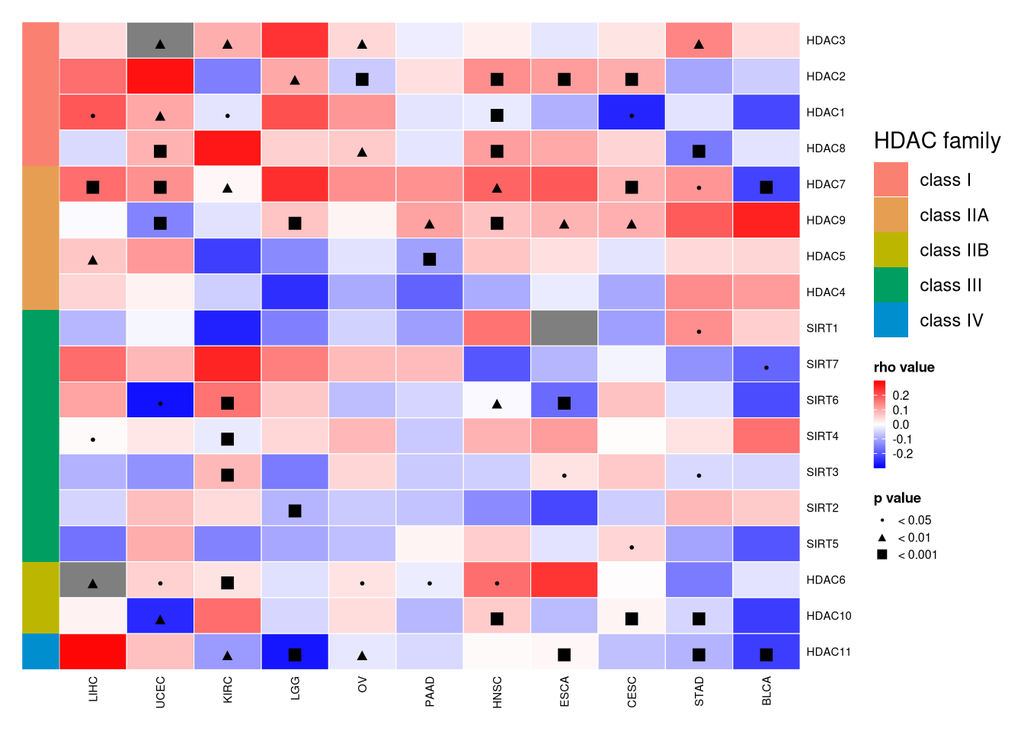

```r
#heatmap + adnotations
final_plot <- p_annot + p_heatmap +
  plot_layout(widths = c(1, 20), guides = 'collect')

final_plot
```

# FIGURE 1B

## 2.1 Cleaning and numbering the “Stage”

```r
print(unique(my_data$Stage))
```

```
 [1] "STAGE IV"         "STAGE III"        "STAGE II"         "STAGE I"
 [5] NA                 "STAGE X"          "STAGE IIB"        "STAGE IA"
 [9] "STAGE IIIA"       "STAGE IIA"        "STAGE IIIC"       "STAGE IB"
[13] "STAGE IIIB"       "STAGE IVA"        "STAGE IIC"        "STAGE IVB"
[17] "STAGE IVC"        "STAGE I/II (NOS)" "STAGE 0"          "STAGE IS"
```

```r
#convert descriptive text values to numierc values to enable statistical calculations
changed_data_for_stage <-my_data %>%
  mutate( Stage_in_numbers =
            case_when(
            Stage == "STAGE 0" ~ 0,
            Stage == "STAGE IS" ~ 0,
            Stage %in% c("STAGE I", "STAGE IA", "STAGE IB") ~ 1,
            Stage %in% c("STAGE II", "STAGE IIA", "STAGE IIB", "STAGE IIC") ~ 2,
            Stage %in% c("STAGE III", "STAGE IIIA", "STAGE IIIB", "STAGE IIIC") ~ 3,
            Stage %in% c("STAGE IV", "STAGE IVA", "STAGE IVB", "STAGE IVC") ~ 4,
            Stage == "STAGE I/II (NOS)" ~ 1.5,
            Stage == "STAGE X" ~ NA,
            TRUE ~ NA
            )
  )
view(changed_data_for_stage)
```

## 2.2 Standardization of tumor names

- long names from TCGA database are converted to short abbreviations

```r
changed_data_for_stage$Cancer <- dplyr::recode(changed_data_for_stage$Cancer,
  "blca_tcga_pan_can_atlas_2018"    = "BLCA",
  "brca_tcga_pan_can_atlas_2018"    = "BRCA",
  "cesc_tcga_pan_can_atlas_2018"    = "CESC",
  "coadread_tcga_pan_can_atlas_2018"= "COAD",
  "esca_tcga_pan_can_atlas_2018"    = "ESCA",
  "gbm_tcga_pan_can_atlas_2018"     = "GBM",
  "hnsc_tcga_pan_can_atlas_2018"    = "HNSC",
  "kirc_tcga_pan_can_atlas_2018"    = "KIRC",
  "kirp_tcga_pan_can_atlas_2018"    = "KIRP",
  "lgg_tcga_pan_can_atlas_2018"     = "LGG",
  "lihc_tcga_pan_can_atlas_2018"    = "LIHC",
  "luad_tcga_pan_can_atlas_2018"    = "LUAD",
  "lusc_tcga_pan_can_atlas_2018"    = "LUSC",
  "ov_tcga_pan_can_atlas_2018"      = "OV",
  "paad_tcga_pan_can_atlas_2018"    = "PAAD",
  "prad_tcga_pan_can_atlas_2018"    = "PRAD",
  "sarc_tcga_pan_can_atlas_2018"    = "SARC",
  "skcm_tcga_pan_can_atlas_2018"    = "SKCM",
  "stad_tcga_pan_can_atlas_2018"    = "STAD",
  "tgct_tcga_pan_can_atlas_2018"    = "TGCT",
  "thca_tcga_pan_can_atlas_2018"    = "THCA",
  "ucec_tcga_pan_can_atlas_2018"    = "UCEC"
)


cancer_order_stage <- c(
  "TGCT", "KIRC", "KIRP", "ESCA",
  "COAD", "LIHC", "HNSC", "BRCA", "LUSC", "SKCM",
  "THCA", "LUAD", "STAD", "BLCA", "PAAD"
)
cancers_use_stage <- intersect(cancer_order_stage, unique(changed_data_for_stage$Cancer))

changed_data_for_stage <- changed_data_for_stage %>%
  filter(Cancer %in% cancers_use_stage)

changed_data_for_stage$Cancer <- factor(changed_data_for_stage$Cancer,
                              levels = cancers_use_stage)
```

## 2.3 Selection of genes for analysis

```r
#here we define genes in the order for the graph
genes_to_test_stage <- c(
#class I
  "HDAC8", "HDAC3", "HDAC2", "HDAC1",
#class IV
  "HDAC11",
#class IIB
  "HDAC10", "HDAC6",
#class IIA
  "HDAC7", "HDAC9", "HDAC5", "HDAC4",
#class III
  "SIRT7", "SIRT2", "SIRT6", "SIRT4", "SIRT1", "SIRT3", "SIRT5"

)
```

## 2.4 Statistical calculations- correlation

```r
#correlation for each pair
s_correlation_stage <- changed_data_for_stage %>%
  pivot_longer(
    cols = any_of(genes_to_test_stage),
    names_to = "gene",
    values_to = "expression"
  ) %>%
  #group for each pair (gene + cancer)
group_by(Cancer, gene) %>%
summarize(
    summary_test_stage = broom::tidy(cor.test(expression, Stage_in_numbers, method ="spearman", exact = FALSE)), .groups = "drop"
  ) %>%
  unnest(summary_test_stage) %>%
  select(Cancer, gene, rho = estimate, p.value)
```

## 2.5 Matrix_rho

```r
matrix_rho_stage <- s_correlation_stage %>%
  select(gene, Cancer, rho) %>%
  pivot_wider(
    names_from = Cancer,
    values_from = rho
  ) %>%
  column_to_rownames("gene") %>%
  as.matrix()
```

## 2.6 Matrix_p

```r
matrix_p_stage <- s_correlation_stage %>%
  select(gene, Cancer, p.value) %>%
  pivot_wider(
    names_from = Cancer,
    values_from = p.value
  ) %>%
  column_to_rownames("gene") %>%
  as.matrix()

#filtering and sorting- without that R will sort the genes by alphabet
final_genes_stage <- genes_to_test_stage[genes_to_test_stage %in% rownames(matrix_rho_stage)]
final_cancers_stage <- cancers_use_stage[cancers_use_stage %in% colnames(matrix_rho_stage)]

#sorted versions
matrix_rho_stage <- matrix_rho_stage[final_genes_stage, final_cancers_stage, drop = FALSE]
matrix_p_stage   <- matrix_p_stage[final_genes_stage, final_cancers_stage, drop = FALSE]

matrix_rho_plot_stage <- matrix_rho_stage
matrix_rho_plot_stage[is.na(matrix_rho_stage)] <- 0
```

## 2.7 Preparation of the final graph

```r
#adnotations-> annot_row creates a legend, assignment to classes
gene_classes_stage <- c(
  HDAC8="class I",
  HDAC3="class I",
  HDAC2="class I",
  HDAC1="class I",

  HDAC11="class IV",

  HDAC10="class IIB",
  HDAC6="class IIB",

  HDAC7="class IIA",
  HDAC9="class IIA",
  HDAC5="class IIA",
  HDAC4="class IIA",

  SIRT7="class III",
  SIRT2="class III",
  SIRT6="class III",
  SIRT4="class III",
  SIRT1="class III",
  SIRT3="class III",
  SIRT5="class III"
)
#data frame for heat map
annot_df_stage <- data.frame(
  gene = final_genes_stage,
  HDAC_family = gene_classes_stage[final_genes_stage])

#BH correction for many tests- reduces fake positives
matrix_p_dot <- matrix(p.adjust(as.vector(matrix_p_stage), method = "BH"),
                       ncol = ncol(matrix_p_stage),
                       nrow = nrow(matrix_p_stage),
                       byrow = FALSE)

#adding markers depending on p value
display_matrix_stage <-
  ifelse(matrix_p_dot < 0.001, "■",
  ifelse(matrix_p_dot < 0.01,  "▲",
  ifelse(matrix_p_dot < 0.05,  "•", "")))

#color palette
my_breaks_stage <- seq(-0.3, 0.3, length.out = 100)

my_colours_stage <- colorRampPalette(c("blue","white", "red"))(100)

# data preparation for ggplot
df_long_stage <- matrix_rho_plot_stage %>%
  as.data.frame() %>%
  rownames_to_column("gene") %>%
  pivot_longer(-gene, names_to = "Cancer", values_to = "value")

df_long_stage$Cancer <- factor(df_long_stage$Cancer, levels = cancer_order_stage)

df_long_stage$label <- as.character(display_matrix_stage)

#adnotations panel
p_annot_stage <- ggplot(annot_df_stage, aes(
    x=1,
    y=factor(gene, levels=rev(final_genes_stage)),
    fill=HDAC_family)) +
  geom_tile() +
  scale_fill_manual(values=c(
    "class I"="salmon",
    "class IIA"="#E69F52",
    "class IIB"="#BDB600",
    "class III"="#009E60",
    "class IV"="#008ECE")) +
  scale_y_discrete(expand = c(0, 0)) +
  scale_x_continuous(expand = c(0, 0)) +
  labs(y = "HDAC family", fill = "HDAC family") +
  theme_void() +
  theme(
    plot.margin = margin(t = 5.5, r = 0, b = 5.5, l = 5.5)
    ) +
  labs(fill = "HDAC family") +
  guides(fill = guide_legend(title = "HDAC family", order = 1))
```

## 2.8 Drawing a graph

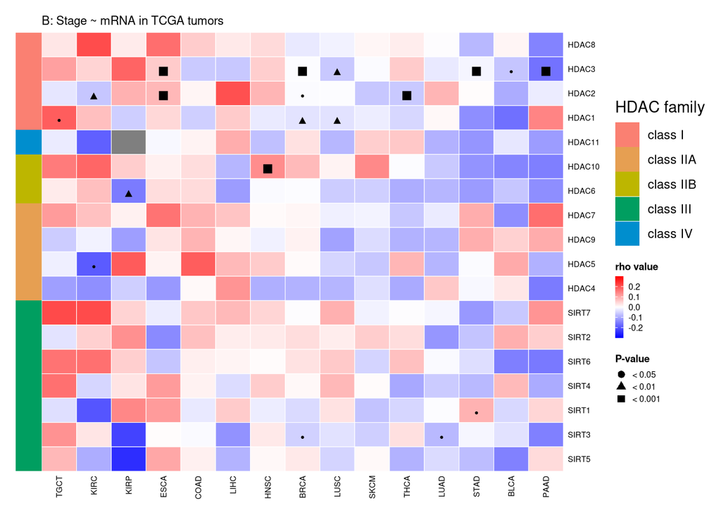

```r
p_heatmap_stage <- ggplot(df_long_stage,
                          aes(x=Cancer,y=factor(gene, levels=rev(final_genes_stage)), fill=value)) +
  geom_tile(color = "white", size = 0.2) +
  geom_point(aes(shape = label), size = 0, alpha = 0) +
  geom_text(aes(label=label), size=3, vjust = 0.75) +
  scale_fill_gradientn(colors=my_colours_stage,
                       limits=c(-0.3,0.3),
                       name = "rho value",
                       guide = guide_colorbar(order = 2, barwidth = 0.4, barheight = 3)) +
  scale_shape_manual(name = "P-value",
                     values = c("•" = 16, "▲" = 17, "■" = 15),
                     breaks = c("•", "▲", "■"),
                     labels = c("< 0.05", "< 0.01", "< 0.001"),
                     na.translate = FALSE) +
  scale_y_discrete(expand = c(0, 0), position = "right") +
  scale_x_discrete(expand = c(0, 0)) +
  theme_minimal(base_size=7) +
  theme(
    axis.text.x = element_text(angle=90, vjust=0.5, hjust = 1, color = "black"),
    axis.text.y = element_text(color = "black"),
    axis.title = element_blank(),
    panel.grid = element_blank(),
    plot.margin = margin(t = 5.5, r = 5.5, b = 5.5, l = 0),
    legend.position = "right",
    legend.key.size = unit(0.3, "cm"),
    legend.text = element_text(size = 6),
    legend.title = element_text(size = 7, face = "bold"),
    legend.spacing.y = unit(0.1, "cm"),
    legend.margin = margin(0,0,0,0)
  ) +
  guides(shape = guide_legend(override.aes = list(alpha = 1, size = 2), order = 3)
  ) +
  labs(title="B: Stage ~ mRNA in TCGA tumors")


#heatmap + adnotations
final_plot_stage <- p_annot_stage + p_heatmap_stage +
  plot_layout(widths = c(1, 20), guides = 'collect')

final_plot_stage
```

## Save

```r
library(here)
here::here()
```

```
[1] "/net/pupil1/home/people/s243548/projects/group_18_project"
```

```r
ggsave(
  filename = here("results", "05_heatmap_for_grade.png"),
  plot = final_plot,
  width = 8,
  height = 8
)
ggsave(
  filename = here("results", "05_heatmap_for_stage.png"),
  plot = final_plot_stage,
  width = 8,
  height = 8
)
```

# 06 Analysis Part 2

## Load Libraries

```r
library(tidyverse)
library(broom)
library(patchwork)
```

## Load data

```r
my_data <- read_csv("../data/02_dat_clean.csv", show_col_types = FALSE)
#view(my_data)
```

## 1. Filtering only the samples with mRNAsi

```r
data_for_stemness <- my_data %>% drop_na(mRNAsi)
```

## 2. Standardization of tumor names

```r
data_for_stemness$Cancer <- dplyr::recode(data_for_stemness$Cancer,
  "blca_tcga_pan_can_atlas_2018"    = "BLCA",
  "brca_tcga_pan_can_atlas_2018"    = "BRCA",
  "cesc_tcga_pan_can_atlas_2018"    = "CESC",
  "coadread_tcga_pan_can_atlas_2018"= "COAD",
  "esca_tcga_pan_can_atlas_2018"    = "ESCA",
  "gbm_tcga_pan_can_atlas_2018"     = "GBM",
  "hnsc_tcga_pan_can_atlas_2018"    = "HNSC",
  "kirc_tcga_pan_can_atlas_2018"    = "KIRC",
  "kirp_tcga_pan_can_atlas_2018"    = "KIRP",
  "lgg_tcga_pan_can_atlas_2018"     = "LGG",
  "lihc_tcga_pan_can_atlas_2018"    = "LIHC",
  "luad_tcga_pan_can_atlas_2018"    = "LUAD",
  "lusc_tcga_pan_can_atlas_2018"    = "LUSC",
  "ov_tcga_pan_can_atlas_2018"      = "OV",
  "paad_tcga_pan_can_atlas_2018"    = "PAAD",
  "prad_tcga_pan_can_atlas_2018"    = "PRAD",
  "sarc_tcga_pan_can_atlas_2018"    = "SARC",
  "skcm_tcga_pan_can_atlas_2018"    = "SKCM",
  "stad_tcga_pan_can_atlas_2018"    = "STAD",
  "tgct_tcga_pan_can_atlas_2018"    = "TGCT",
  "thca_tcga_pan_can_atlas_2018"    = "THCA",
  "ucec_tcga_pan_can_atlas_2018"    = "UCEC"
)

cancers_use_stemness <- unique(data_for_stemness$Cancer)
```

## 3. Selection of genes for analysis

```r
genes_to_test_stemness <- c(
  "HDAC4", "HDAC5", "HDAC9", "HDAC7", # class IIA
  "HDAC10", "HDAC6",                  # class IIB
  "SIRT5", "SIRT7", "SIRT6", "SIRT3", "SIRT4", "SIRT2", "SIRT1", # class III
  "HDAC11",                           # class IV
  "HDAC2", "HDAC3", "HDAC8", "HDAC1"  # class I
)
```

## 4. Computation of Spearman correlations between gene expression and mRNAsi.

Steps: reshape data, group by Cancer and gene, run cor.test, extract rho (correlation) and p-value.

```r
s_correlation_stemness <- data_for_stemness %>%
  pivot_longer(cols = any_of(genes_to_test_stemness),
               names_to = "gene", values_to = "expression") %>%
  group_by(Cancer, gene) %>%
  summarize(summary_test = broom::tidy(cor.test(expression, mRNAsi, method = "spearman", exact = FALSE)),
            .groups = "drop") %>%
  unnest(summary_test) %>%
  select(Cancer, gene, rho = estimate, p.value)
```

## 5. Adjustment p-values using Benjamini–Hochberg (BH) correction to control false positives.

Create a “label” column with symbols showing significance levels.

```r
s_correlation_stemness <- s_correlation_stemness %>%
  mutate(p.adj = p.adjust(p.value, method = "BH"),
         label = case_when(
           p.adj < 0.001 ~ "■",
           p.adj < 0.01  ~ "▲",
           p.adj < 0.05  ~ "•",
           TRUE ~ ""
         ))
```

## 6. Definition of gene classes (I, IIA, IIB, III, IV) and assignment of each geneto its corresponding family.

Creation a data frame (annot_df) linking genes to HDAC/SIRT classes for annotation in the heatmap.

```r
gene_classes <- c(
  HDAC3="class I", HDAC2="class I", HDAC1="class I", HDAC8="class I",
  HDAC7="class IIA", HDAC9="class IIA", HDAC5="class IIA", HDAC4="class IIA",
  SIRT1="class III", SIRT7="class III", SIRT6="class III", SIRT4="class III",
  SIRT3="class III", SIRT2="class III", SIRT5="class III",
  HDAC6="class IIB", HDAC10="class IIB", HDAC11="class IV"
)

annot_df <- data.frame(
  gene = genes_to_test_stemness,
  HDAC_family = gene_classes[genes_to_test_stemness]
)
```

## 7. Creation of the heatmap of Spearman correlations (rho) between gene expression and mRNAsi.

- x-axis: Cancer types
- y-axis: Genes (ordered, reversed for display)
- fill color: correlation coefficient (blue = negative, red = positive)
- overlay symbols (■, ▲, •) showing significance levels

```r
p_heatmap <- ggplot(s_correlation_stemness,
                    aes(x = Cancer,
                        y = factor(gene, levels = rev(genes_to_test_stemness)),
                        fill = rho)) +
  geom_tile(color = "white", size = 0.2) +
  geom_text(aes(label = label), size = 3, vjust = 0.75) +
  scale_fill_gradientn(colors = colorRampPalette(c("blue", "white", "red"))(101),
                       limits = c(-0.7, 0.8),
                       name = "rho value") +
  scale_y_discrete(expand = c(0, 0), position = "right") +
  scale_x_discrete(expand = c(0, 0)) +
  theme_minimal(base_size = 7) +
  theme(
    axis.text.x = element_text(angle = 90, vjust = 0.5, hjust = 1, color = "black"),
    axis.text.y = element_text(color = "black"),
    axis.title = element_blank(),
    panel.grid = element_blank(),
    plot.margin = margin(t = 5.5, r = 5.5, b = 5.5, l = 0),
    legend.position = "right"
  ) +
  labs(title = "mRNAsi vs HDAC expression in TCGA tumors")
```

## 8. Creation of the annotation panel showing gene classes (HDAC families).

Each gene is displayed as a tile, colored by its family (I, IIA, IIB, III, IV).

```r
p_annot <- ggplot(annot_df, aes(
    x = 1,
    y = factor(gene, levels = rev(genes_to_test_stemness)),
    fill = HDAC_family)) +
  geom_tile() +
  scale_fill_manual(values = c(
    "class I"="salmon",
    "class IIA"="#E69F52",
    "class IIB"="#BDB600",
    "class III"="#009E60",
    "class IV"="#008ECE")) +
  scale_y_discrete(expand = c(0, 0)) +
  scale_x_continuous(expand = c(0, 0)) +
  labs(y = "HDAC family", fill = "HDAC family") +
  theme_void() +
  theme(plot.margin = margin(t = 5.5, r = 0, b = 5.5, l = 5.5))
```

## 9. Combine annotation panel and heatmap into one figure.

Show the plot and save it as PNG.

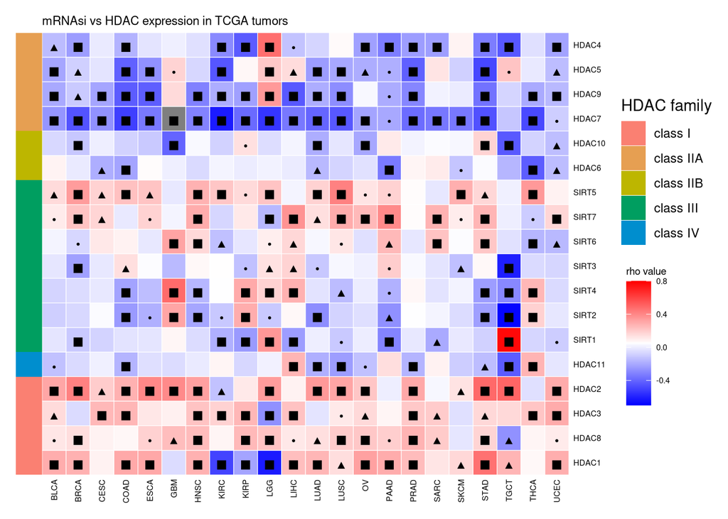

```r
final_plot <- p_annot + p_heatmap + plot_layout(widths = c(1, 20), guides = "collect")
final_plot
```

```r
ggsave("../results/heatmap_stemness.png", plot = final_plot, width = 8, height = 6, dpi = 300)
```

# 07 Analysis Part 3

## Load libraries

```r
library(tidyverse)
library(ggplot2)
library(patchwork)
library(cowplot)
library(survival)
```

## Load data

```r
#Get data from our augment file
dat_aug <- read.csv("../data/03_dat_aug.csv")
```

## Data changes

#### Define list of genes

```r
# define list of genes
genes <- c(paste0("HDAC", 1:11), paste0("SIRT", 1:7))

genes
```

```
 [1] "HDAC1"  "HDAC2"  "HDAC3"  "HDAC4"  "HDAC5"  "HDAC6"  "HDAC7"  "HDAC8"
 [9] "HDAC9"  "HDAC10" "HDAC11" "SIRT1"  "SIRT2"  "SIRT3"  "SIRT4"  "SIRT5"
[17] "SIRT6"  "SIRT7"
```

#### Fix OS and DFS status to numerical values

In the data, for both OS and DFS the status was not numerical, but in stead “1:DECEASED” etc. We want to transform these values into numerical ones.

```r
#Fix OS and DFS status to numeric 0/1

#cols treated as character strings, because after case_when needs exact text values
dat_aug$OS_STATUS  <- as.character(dat_aug$OS_STATUS)
dat_aug$DFS_STATUS <- as.character(dat_aug$DFS_STATUS)

#convert OS to 0/1
dat_aug$OS_STATUS <- case_when(
  dat_aug$OS_STATUS == "1:DECEASED" ~ 1,
  dat_aug$OS_STATUS == "0:LIVING"   ~ 0,
  TRUE ~ NA_real_
)
#convert DFS to 0/1
dat_aug$DFS_STATUS <- case_when(
  dat_aug$DFS_STATUS == "1:Recurred/Progressed" ~ 1,
  dat_aug$DFS_STATUS == "0:DiseaseFree"         ~ 0,
  TRUE ~ NA_real_
)

#NA_real_ = numeric version of NA: needed for missing or unexpected values
```

#### Transform data

To ensure genes are comparable across cancvers and the cox model (later) will run well, the data has to be transformed.

We standardize the gene expression values within each cancer type.

-> Apply z-score scaling: (value - mean) / SD

```r
# transform gene expression
dat_aug <- dat_aug |>
  group_by(Cancer) |>
  mutate(across(all_of(genes), scale)) |>
  ungroup()
```

## Create matrices

First split by cancers: rows for the genes and columns for the cancer types

Then create empty matrices to later be filled with Cox function values

#### Create empty matrices

```r
#split data into list by cancer types
#each element contains only one cancer's samples
split_cancers <- split(dat_aug, dat_aug$Cancer)

#create empty matrices
#rows = genes, cols = cancers
#filled with NA_real_, later replaced with Cox model values

#OS
mat_hr_os <- matrix(
  NA_real_,
  nrow = length(genes),
  ncol = length(split_cancers),
  dimnames = list(genes, names(split_cancers))
)
mat_pval_os <- mat_hr_os

#DFS
#same way OS
mat_hr_dfs <- matrix(
  NA_real_,
  nrow = length(genes),
  ncol = length(split_cancers),
  dimnames = list(genes, names(split_cancers))
)
mat_pval_dfs <- mat_hr_dfs

#check matrix dimensions
dim(mat_hr_os)
```

```
[1] 18 22
```

```r
dim(mat_pval_os)
```

```
[1] 18 22
```

```r
dim(mat_hr_dfs)
```

```
[1] 18 22
```

```r
dim(mat_pval_dfs)
```

```
[1] 18 22
```

```r
#should be 18x22
```

#### Define Cox model

The cox hazard model is a statistical technique used for survival analysis. It estimates the hazard ratio HR.

Function to not have to repeat for every combination of genes and cancer types separately

```r
# create cox_single_gene function: cox hazard analysis for one gene in one cancer type
#returns log10 hr and p-value

cox_single_gene <- function(cancer_data, time_col, status_col, gene) {
  #data frame 1 cancer type, survival time column OS/DFS, status col 0/1, gene for hr

#temporary data set d
  d <- cancer_data[, c(time_col,
                       status_col,
                       gene)] #select necessary col
  d <- d[complete.cases(d), ] #remove rows with missing data = contain any NA

#check for minimum smaple size
# <5 is too few to run Cox model -> function aborts
  if (nrow(d) < 5) {
    return(list(log10HR = NA,
                pvalue = NA))
  }

#split expression in high vs low group
  #calc median expression of gene & create binary value: 1 for high, 0 for low
  med <- median(d[[gene]],
                na.rm = TRUE)
d$expr_group <- ifelse(d[[gene]] > med, 1, 0)

#fit the cox model with coxph
#try so function does not crash if model fails
fit <- try(coxph(Surv(d[[time_col]],
                      d[[status_col]]) ~ d$expr_group),
           silent = TRUE)

#if model fails, return NA
  if (inherits(fit, "try-error")) {
    return(list(log10HR = NA,
                pvalue = NA))
  }

  #extract HR and p-value
  s <- summary(fit)
  #if summary fails, return NA
  if (is.null(s$coefficients)) {
    return(list(log10HR = NA,
                pvalue = NA))
  }

  #extract hazard ratio and p-value
  hr <- s$coefficients[,"exp(coef)"]
  pval <- s$coefficients[, "Pr(>|z|)"]

  #return log10(HR) and p-value
  list(log10HR = log10(hr), pvalue = pval)

}
```

#### Fill matrices

Fill the hazard ratio and p-value matrices for each cancer x gene combination.

Do this by extracting the dataset for a specific cancer type, run the cox model on it, and save it in a matrix

```r
#fill matrices

# OS
for (cn in names(split_cancers)) {
  dat_c <- split_cancers[[cn]] #extract data per cancer type into new dataset

  for (g in genes) { #for each gene....
    res <- cox_single_gene( #....run cox model
      cancer_data = dat_c,
      time_col = "OS_MONTHS",
      status_col = "OS_STATUS",
      gene = g
    ) #calls cox function and returns hz and pval
    mat_hr_os[g, cn] <- res$log10HR
    mat_pval_os[g, cn] <- res$pvalue
  } #stores results into matrices
}
#DFS
# same method
for (cn in names(split_cancers)) {

  dat_c <- split_cancers[[cn]]   # data for this cancer

  for (g in genes) {

    res <- cox_single_gene(
      cancer_data = dat_c,
      time_col = "DFS_MONTHS",
      status_col = "DFS_STATUS",
      gene = g
    )

    mat_hr_dfs[g, cn]   <- res$log10HR
    mat_pval_dfs[g, cn] <- res$pvalue
  }
}
```

#### Create significance (p-value) symbol matrix

Take p-value matrices and convert them into symbol matrices

Will later be drawn on top of the heatmap

```r
# converting numerical p-values into shape symbols: triangle, square, dot or none

#OS
symbol_mat_os <- ifelse( #create new symbol matrix
  mat_pval_os < 0.001, "\u25B2",   # triangle ▲
  ifelse(
    mat_pval_os < 0.01, "\u25A0",  # square ■
    ifelse(
      mat_pval_os < 0.05, "\u2022", # dot •
      "" #otherwise no symbol
    )
  )
)

#DFS
symbol_mat_dfs <- ifelse(
  mat_pval_dfs < 0.001, "\u25B2",
  ifelse(
    mat_pval_dfs < 0.01,  "\u25A0",
    ifelse(
      mat_pval_dfs < 0.05, "\u2022",
      ""
    )
  )
)

#check dims: 18x22?
dim(symbol_mat_os)
```

```
[1] 18 22
```

```r
dim(symbol_mat_dfs)
```

```
[1] 18 22
```

#### Fix names of cancers

Some cancers have _ in their name: OV_T, GBM_, and LGG_. We want their names to just be OV, GBM, and LGG.

```r
#cleaning function
#gsub replaces substring only when it's found with correct cancer abbreviations
fix_names <- function(mat) {
  colnames(mat) <- gsub("OV_T", "OV", colnames(mat))
  colnames(mat) <- gsub("GBM_", "GBM", colnames(mat))
  colnames(mat) <- gsub("LGG_", "LGG", colnames(mat))
  mat
}

#all matrices need the new names, so apply function to all hr, pval and symbol matrices for OS and DFS
mat_hr_os      <- fix_names(mat_hr_os)
mat_pval_os    <- fix_names(mat_pval_os)
symbol_mat_os  <- fix_names(symbol_mat_os)

mat_hr_dfs     <- fix_names(mat_hr_dfs)
mat_pval_dfs   <- fix_names(mat_pval_dfs)
symbol_mat_dfs <- fix_names(symbol_mat_dfs)
```

#### Fix cancer and gene orders by classes

Create a custom gene order for the heatmap, so genes in the same family class can be grouped together

These family classes will be later explored.

```r
# custom cancer order
cancer_order <- c(
  "PRAD","TGCT","THCA","LIHC","COAD","OV","LUSC","GBM",
  "BRCA","LUAD","SARC","ESCA","SKCM","STAD","BLCA","HNSC",
  "PAAD","KIRP","UCEC","LGG","KIRC"
)

#apply order to all matrices
#cancers are columns so after komma
#OS
mat_hr_os   <- mat_hr_os[, cancer_order]
mat_pval_os <- mat_pval_os[, cancer_order]
symbol_mat_os  <- symbol_mat_os[, cancer_order]
#DFS
mat_hr_dfs   <- mat_hr_dfs[, cancer_order]
mat_pval_dfs <- mat_pval_dfs[, cancer_order]
symbol_mat_dfs  <- symbol_mat_dfs[, cancer_order]

#Fix gene order (rows) by HDAC/SIRT family class structure
gene_order <- c(
  "HDAC10","HDAC6","HDAC1","HDAC8","HDAC3","HDAC2",
  "SIRT7","SIRT3","SIRT6","SIRT1","SIRT2","SIRT5","SIRT4",
  "HDAC7","HDAC4","HDAC9","HDAC5","HDAC11"
)

#apply to all matrices
#genes = rows, so before komma
mat_hr_os   <- mat_hr_os[gene_order, ]
mat_pval_os <- mat_pval_os[gene_order, ]
symbol_mat_os  <- symbol_mat_os[gene_order, ]

mat_hr_dfs   <- mat_hr_dfs[gene_order, ]
mat_pval_dfs <- mat_pval_dfs[gene_order, ]
symbol_mat_dfs  <- symbol_mat_dfs[gene_order, ]

#check order
rownames(mat_hr_os)
```

```
 [1] "HDAC10" "HDAC6"  "HDAC1"  "HDAC8"  "HDAC3"  "HDAC2"  "SIRT7"  "SIRT3"
 [9] "SIRT6"  "SIRT1"  "SIRT2"  "SIRT5"  "SIRT4"  "HDAC7"  "HDAC4"  "HDAC9"
[17] "HDAC5"  "HDAC11"
```

```r
colnames(mat_hr_os)
```

```
 [1] "PRAD" "TGCT" "THCA" "LIHC" "COAD" "OV"   "LUSC" "GBM"  "BRCA" "LUAD"
[11] "SARC" "ESCA" "SKCM" "STAD" "BLCA" "HNSC" "PAAD" "KIRP" "UCEC" "LGG"
[21] "KIRC"
```

#### Drop NA columns

Some cancer types turned out to only contain NA values in their columns.

In DFS these were GBM and SKCM. To make sure no columns without values were present in the heatmaps, we drop them here.

```r
#count how many NA values are in each column
#col kept if at least 1 entry is not NA
#drop = FALSE prevents R from turning 1-col matrix into vector

drop_all_na_cols <- function(mat) {
  keep <- colSums(is.na(mat)) < nrow(mat)
  mat[, keep, drop = FALSE]
}

#apply to all matrices
mat_hr_os     <- drop_all_na_cols(mat_hr_os)
mat_pval_os   <- drop_all_na_cols(mat_pval_os)
symbol_mat_os <- drop_all_na_cols(symbol_mat_os)

mat_hr_dfs     <- drop_all_na_cols(mat_hr_dfs)
mat_pval_dfs   <- drop_all_na_cols(mat_pval_dfs)
symbol_mat_dfs <- drop_all_na_cols(symbol_mat_dfs)
```

## Preparations: building heatmap

#### Family information and coloring

```r
#extract final gene and cancer order
#determine structure heatmap
gene_order <- rownames(mat_hr_os)
cancer_order <- colnames(mat_hr_os)

# create table: assigns genes to families
family_df <- tibble(
  gene = gene_order,
  family = case_when(
    gene %in% c("HDAC1","HDAC2","HDAC3","HDAC8") ~ "class I",
    gene %in% c("HDAC4","HDAC5","HDAC7","HDAC9") ~ "class IIA",
    gene %in% c("HDAC6","HDAC10")                ~ "class IIB",
    gene %in% c("HDAC11")                        ~ "class IV",
    gene %in% c("SIRT1","SIRT2","SIRT3","SIRT4","SIRT5","SIRT6","SIRT7") ~ "class III"
  )
)

# colourcode families
family_colors <- c(
  "class I"  = "#F26684",
  "class IIA"= "#E0E048",
  "class IIB"= "#48B558",
  "class III"= "#579FD9",
  "class IV" = "#2013AD"
)
```

#### Matrices into tidy long format for ggplot

Ggplot can only work with long format data, so we have to convert the data into it.

```r
#convert matrices and family table into one tidy dataframe
mat_to_long <- function(mat_hr,
                        mat_p,
                        mat_sym,
                        family_df,
                        gene_order,
                        cancer_order) {

  #convert hr matrix into long format
  df_hr <- mat_hr |>
    as.data.frame() |> #conv into data frame
    rownames_to_column("gene") |> #moves matrix row names unto column
    pivot_longer(-gene,
                 names_to = "Cancer",
                 values_to = "log10HR") #converts from wide to long format

  #same for pval matrix
  df_p <- mat_p |>
    as.data.frame() |>
    rownames_to_column("gene") |>
    pivot_longer(-gene, names_to = "Cancer", values_to = "pval")

  #same for symbol matrix
  df_sym <- mat_sym |>
    as.data.frame() |>
    rownames_to_column("gene") |>
    pivot_longer(-gene, names_to = "Cancer", values_to = "symbol")

  #merge the three dataframes + family annotation
  df <- df_hr |>
    left_join(df_p, by = c("gene","Cancer")) |>
    left_join(df_sym, by = c("gene","Cancer")) |>
    left_join(family_df, by = "gene")

  #convert gene and cancer variables into ordered factors
  #ensures ggplot plots rown and columns in before defined order
  df$gene   <- factor(df$gene, levels = gene_order)
  df$Cancer <- factor(df$Cancer, levels = cancer_order)

  #return final tidy dataframe
  df
}
```

#### Tidy dataframes for OS and DFS

```r
#OS
#use mat_to_long function os os and dfs matrices now
df_os  <- mat_to_long(mat_hr_os,
                      mat_pval_os,
                      symbol_mat_os,
                      family_df,
                      gene_order,
                      cancer_order)

#clipping of values into range[-1, 1]
#extreme values cannot distort heatmap color scale
#reset cancer factor levels to ensure custom order
df_os <- df_os |>
  mutate(log10HR_clip = pmax(pmin(log10HR, 1), -1))|>
  mutate(Cancer = factor(Cancer, levels = cancer_order))

#for the legends
#translate p-vlaues into shape names
#define as factor for consistent legend ordering
df_os <- df_os |>
  mutate(p_shape = case_when(
      pval < 0.001 ~ "triangle",
      pval < 0.01  ~ "square",
      pval < 0.05  ~ "circle",
      TRUE ~ NA_character_
      ),
    p_shape = factor(p_shape, levels = c("circle", "square", "triangle"))
  )

#DFS
#same methods
#... removal of cancers with no DFS data, otherwise blank columns
df_dfs <- mat_to_long(mat_hr_dfs, mat_pval_dfs, symbol_mat_dfs,
                      family_df, gene_order, cancer_order)

df_dfs <- df_dfs |>
  mutate(log10HR_clip = pmax(pmin(log10HR, 1), -1)) |>
  filter(!Cancer %in% c("GBM", "SKCM")) |># those cancers NA & don't want those in plot
  droplevels() |>
  mutate(Cancer = factor(Cancer,
                         levels = cancer_order[cancer_order %in% Cancer]))


#same as for os
df_dfs <- df_dfs |>  #for the legends
  mutate(p_shape = case_when(
      pval < 0.001 ~ "triangle",
      pval < 0.01  ~ "square",
      pval < 0.05  ~ "circle",
      TRUE ~ NA_character_
      ),
    p_shape = factor(p_shape, levels = c("circle", "square", "triangle"))
  )
```

## Building the plot: family bar, heatmap, and legends

There are to be made multiple seperate elements for the final plot.

1. The heatmap, with colored tiles for the hazard ratios (HR), and symbols that show the P-value for every tile
2. On the left, a colored bar that show the family classes that the genes are in
3. On the right 3 legends:
   - One that shows the gradient of the hazard ratios, relating to the coloring of the tiles
   - One that shows the different family classes, relating to the coloring of the bar
   - One that shows the meaning of the symbols, corresponding to the symbols on the heatmap tiles.

#### Family bar and legend

Bar

```r
#first create the bar

#function using long format df, correct gene order and family color mapping
make_family_bar <- function(df,
                            gene_order,
                            family_colors) {

  #keep unique gene-family pairs
  #table with row for gene and assigned family
  df_unique <- df |>
    distinct(gene, family) |>
    mutate(gene = factor(gene,
                         levels = gene_order)) #correct row order

  #build the bar
  ggplot(df_unique, aes(x = 1, #thin column
                        y = gene, #tile per gene
                        fill = family)) + #color from family class
    geom_tile() + #solid rectangles
    scale_fill_manual(values = family_colors,
                      name = "HDAC family") + #add family colors
    scale_y_discrete(limits = rev(gene_order)) + #reverse y-axis order to match heatmap
    theme_void() + #remove everything else
    theme(
      legend.position = "none",
      plot.margin = margin(0, 0, 0, 0)
    )
}

#generate bar for OS and DFS
family_bar_os <- make_family_bar(df_os,
                                 gene_order,
                                 family_colors)
family_bar_dfs <- make_family_bar(df_dfs,
                                  gene_order,
                                  family_colors)
```

Legend

```r
#then the legend

#data frame with one row per family in correct order
family_legend_df <- data.frame(
  family = factor(
    c("class I",
      "class IIA",
      "class IIB",
      "class III",
      "class IV"),
    levels = c("class I",
               "class IIA",
               "class IIB",
               "class III",
               "class IV")
  )
)

#small ggplot
family_legend_plot <- ggplot(family_legend_df,
                             aes(x = family,
                                 y = 1,
                                 fill = family)) +
  geom_tile() +
  scale_fill_manual(values = family_colors, #same colors as sidebar
                    name = "HDAC family") +
  theme_void() + #removes unnecessary visuals
  theme(
    legend.position = "right",
    legend.title = element_text(size = 10,
                                face = "bold"),
    legend.text  = element_text(size = 9)
  ) +
  guides(
    fill = guide_legend(
      title.position = "top",
      ncol = 1,
      keyheight = unit(0.5, "cm"),
      keywidth  = unit(0.5, "cm")
    )
  )

#extract it
#wrap_elements() for placement in patchwork layout
family_legend <- cowplot::get_legend(family_legend_plot)
family_legend_wrap <- patchwork::wrap_elements(full = family_legend)
```

#### P-value legend

```r
#create dataframe containing p-value shape categories
# 3 rows for each symbol & defines factor with controlled order
pval_leg_df <- data.frame(
  p_shape = factor(
    c("circle", "square", "triangle"),
    levels = c("circle", "square", "triangle")
  )
)

#ggplot: maps shape to pval class
pval_leg_plot <- ggplot(pval_leg_df,
                        aes(x = 1,
                            y = p_shape,
                            shape = p_shape)) +
  geom_point(size = 3, #draws shapes
             color = "black") +
  scale_shape_manual( #map shapes to ggplot2 shape code
    values = c(circle = 16,
               square = 15,
               triangle = 17),
    labels = c("<0.05",
               "<0.01",
               "<0.001"),
    name   = "P-value"
  ) +
  guides( #customize legend
    shape = guide_legend(
      title.position = "top",
      label.position = "bottom",
      nrow = 1,
      override.aes = list(size = 4)
    )
  ) +
  theme_void() + #remove axis and grid
  theme(legend.position = "right")

#extract legend using cowplot
pval_legend <- cowplot::get_legend(pval_leg_plot)
pval_legend_wrap <- patchwork::wrap_elements(full = pval_legend)
```

#### HR legend

```r
#create data frame that spans hr range
hr_leg_df <- data.frame(
  x = 1:3,
  y = 1,
  val = seq(-1, 1, length.out = 3)
)

#ggplot bar with gradient fill
hr_leg_plot <- ggplot(hr_leg_df,
                      aes(x,
                          y,
                          fill = val)) +
  geom_tile() +
  scale_fill_gradient2( #define colour scale
    low = "#00A859",
    mid = "white",
    high = "red", #risk
    midpoint = 0,
    name = "Hazard ratio: log10(HR)"
  ) +
  guides(
    fill = guide_colorbar(
      direction = "horizontal", #horizontal bar
      title.position = "top",   # title above
      title.hjust = 0.5,        # center title
      barwidth = unit(3, "cm"),
      barheight = unit(0.3, "cm")
    )
  ) +
  theme_void() +
  theme(legend.position = "right")

#extract legend
hr_legend <- cowplot::get_legend(hr_leg_plot)
hr_legend_wrap <- patchwork::wrap_elements(full = hr_legend)
```

#### Ggplot heatmap

Elements and function:

- Geom_tile(): colored HR blocks
- Geom_point(): significance symbols

```r
#create function for making the heatmap to later apply on os and dfs dataframes
make_hr_heatmap <- function(df, title_text) {
  ggplot(df,
         aes(Cancer,  #x-axis cacncer types
             gene)) + #y-axis genes
    geom_tile(aes(fill = log10HR_clip), #draw tiles of heatmap according to hr values
              color = "white", #thin borders
              width = 0.8,
              linewidth = 0.25) +
    geom_point(aes(shape = factor(p_shape)), #for shapes onto the plot
               size = 2.0,
               color = "black",
               stroke = 0.3,
               na.rm = TRUE
    ) +

    #colour gradient onto plot
    scale_fill_gradient2(
      low = "#00A859",
      mid = "white",
      high = "red",
      midpoint = 0
    ) +

    #define point shapes
    scale_shape_manual(
      values = c("circle" = 16,
                 "square" = 15,
                 "triangle" = 17)
    ) +

     #axis formatting
    scale_x_discrete(position = "bottom",
                     drop = FALSE) +
    scale_y_discrete(
      limits = rev(levels(df$gene)),
      position = "right") +

    labs(title = title_text) +

    theme_minimal(base_size = 10) +
    theme(
      axis.title = element_blank(),
      panel.grid = element_blank(),
      axis.text.x = element_text(angle = 90,
                                 hjust = 0,
                                 vjust = 1),
      axis.text.y = element_text(size = 9),
      strip.text.y = element_blank(),     # removes "class I" texts
      plot.title = element_text(face = "bold",
                                hjust = 0),
      legend.position = "none",
      plot.margin = margin(8, 8, 8, 8)
    )
}
```

#### Heatmaps for OS and DFS

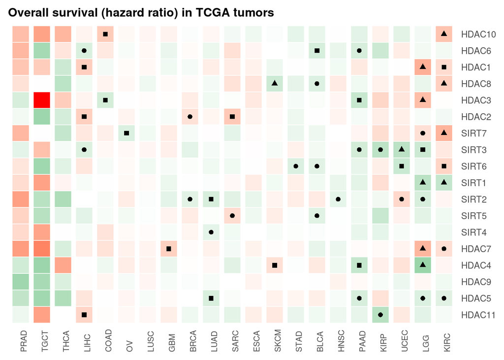

```r
#plot heatmaps with make_heatmap function on tidy data for os and dfs
# name the heatmaps

p_os  <- make_hr_heatmap(df_os,  "Overall survival (hazard ratio) in TCGA tumors")

p_dfs <- make_hr_heatmap(df_dfs, "Disease Free Survival (hazard ratio) in TCGA tumors")

#see plots
p_os
```

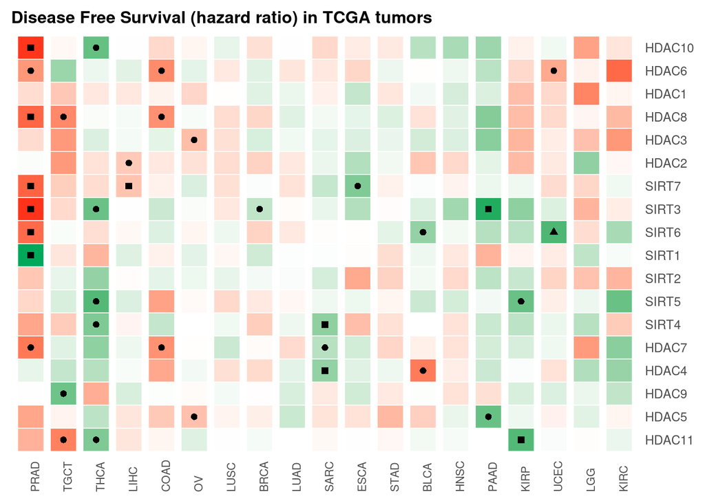

```r
p_dfs
```

#### Final plots of OS and DFS: Bar, heatmap and legends

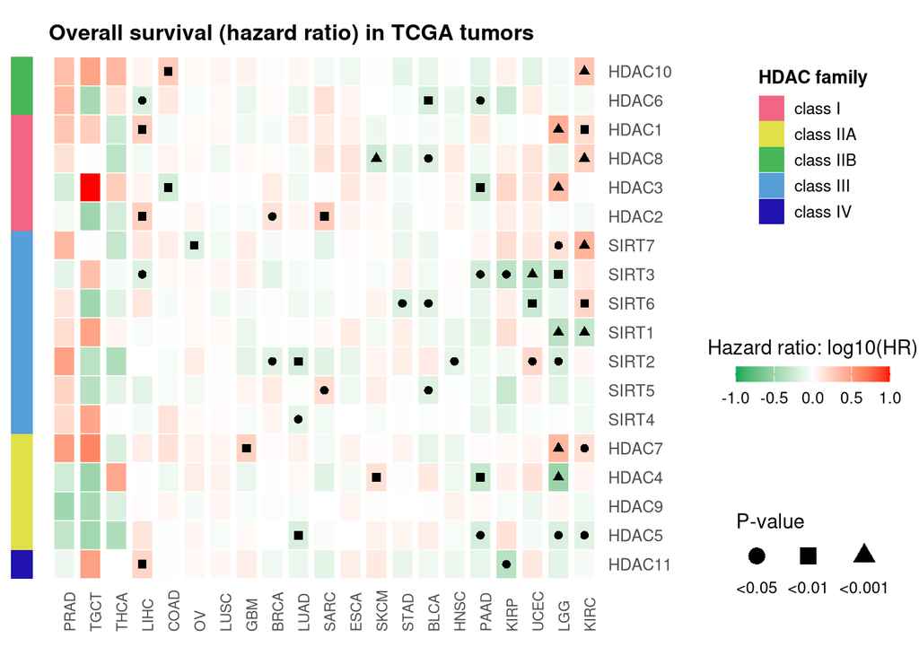

```r
#create spacer for in between elements
spacer <- patchwork::plot_spacer()

# merge the three legends into one element, on top of each other
right_legends <- (
  family_legend_wrap /
  spacer /
  hr_legend_wrap /
  spacer /
  pval_legend_wrap
  ) +
  plot_layout(heights = c(0.40, 0.01, 0.2, 0.01, 0.2))

#create final seperate os and dfs plots
#bar+heatmap+merged legends
final_plot_os <- (
  family_bar_os | p_os | spacer | right_legends
  ) +
  plot_layout(widths = c(0.07, 1.6, 0.03, 0.50))

final_plot_dfs <- (
  family_bar_dfs | p_dfs | spacer | right_legends
  ) +
  plot_layout(widths = c(0.07, 1.6, 0.03, 0.50))

#see plots
final_plot_os
```

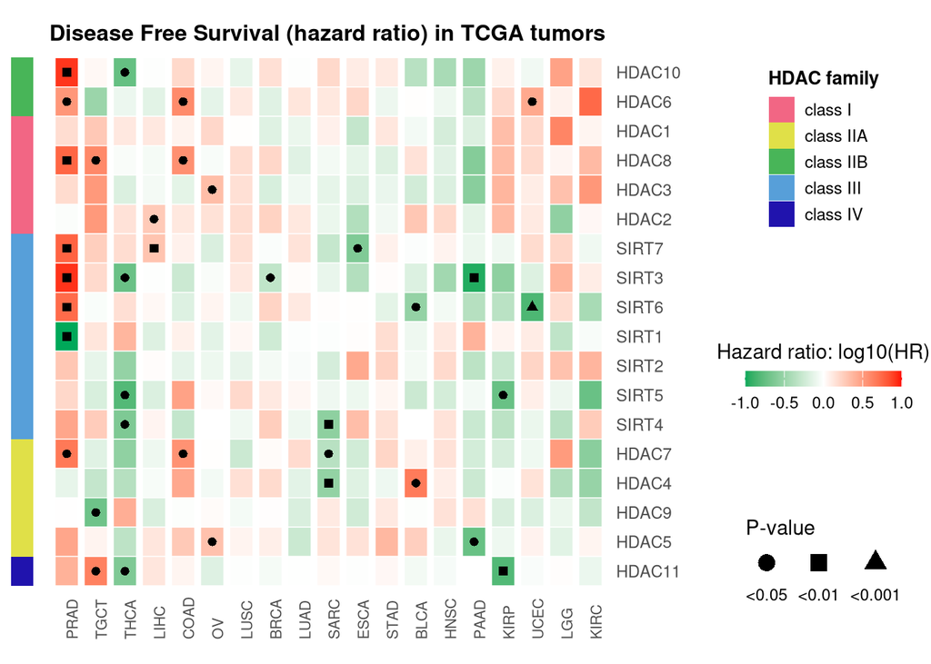

```r
final_plot_dfs
```

```r
ggsave("../results/07_plot_Overall_Survival.png", plot = final_plot_os, width = 8, height = 5, dpi = 300)
ggsave("../results/07_plot_Disease_Free_Survival.png", plot = final_plot_dfs, width = 8, height = 5, dpi = 300)
```

#### Side by side/below each other

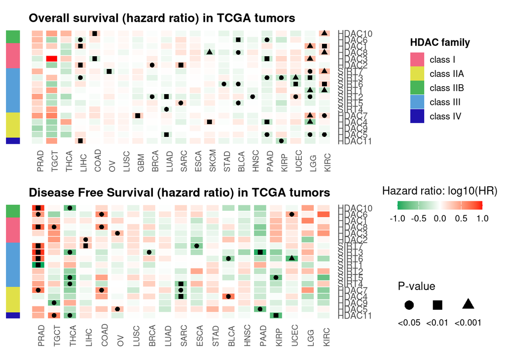

```r
#this was for next to eachother, but no space for nice view of heatmaps
#final_plot <- (
#  family_bar_os | p_os | spacer | family_bar_dfs | p_dfs | spacer | right_legends
#  ) +
#  plot_layout(widths = c(0.07, 1, 0.03, 0.07, 1, 0.03, 0.15))

#merge the family bar and heatmap into one element
os_block <- (family_bar_os | p_os ) +
  plot_layout(widths = c(0.05, 1))
dfs_block <- (family_bar_dfs | p_dfs) +
  plot_layout(widths = c(0.05, 1))

#put these blocks on top of eachother = stack
#same space
stack <- (
  os_block /
  dfs_block
) +
  plot_layout(heights = c(1, 1))

#create final plot with the stack and the right legends next to eachother
final_plot <- (
  stack | right_legends
) +
  plot_layout(widths = c(1, 0.33))

final_plot
```

```r
#save picture externally, for better visuals
#ggsave(
#  "HDAC_OS_DFS_heatmaps.png",
#  final_plot,
#  width = 8,
#  height = 8,
#  dpi = 300
#)
```